# Week-1-Intro

Madeline Carlson

2023-01-25

# Exercise 6.3.1

##1. Why don’t the following lines of code work? Tweak each one so the code runs

```r
myList[["fruit"]]
```

```
## [1] "apple"
```

```r
penguins$flipper_length_mm
```

```
##   [1] 181 186 195  NA 193 190 181 195 193 190 186 180 182 191 198 185 195 197
##  [19] 184 194 174 180 189 185 180 187 183 187 172 180 178 178 188 184 195 196
##  [37] 190 180 181 184 182 195 186 196 185 190 182 179 190 191 186 188 190 200
##  [55] 187 191 186 193 181 194 185 195 185 192 184 192 195 188 190 198 190 190
##  [73] 196 197 190 195 191 184 187 195 189 196 187 193 191 194 190 189 189 190
##  [91] 202 205 185 186 187 208 190 196 178 192 192 203 183 190 193 184 199 190
## [109] 181 197 198 191 193 197 191 196 188 199 189 189 187 198 176 202 186 199
## [127] 191 195 191 210 190 197 193 199 187 190 191 200 185 193 193 187 188 190
## [145] 192 185 190 184 195 193 187 201 211 230 210 218 215 210 211 219 209 215
## [163] 214 216 214 213 210 217 210 221 209 222 218 215 213 215 215 215 216 215
## [181] 210 220 222 209 207 230 220 220 213 219 208 208 208 225 210 216 222 217
## [199] 210 225 213 215 210 220 210 225 217 220 208 220 208 224 208 221 214 231
## [217] 219 230 214 229 220 223 216 221 221 217 216 230 209 220 215 223 212 221
## [235] 212 224 212 228 218 218 212 230 218 228 212 224 214 226 216 222 203 225
## [253] 219 228 215 228 216 215 210 219 208 209 216 229 213 230 217 230 217 222
## [271] 214  NA 215 222 212 213 192 196 193 188 197 198 178 197 195 198 193 194
## [289] 185 201 190 201 197 181 190 195 181 191 187 193 195 197 200 200 191 205
## [307] 187 201 187 203 195 199 195 210 192 205 210 187 196 196 196 201 190 212
## [325] 187 198 199 201 193 203 187 197 191 203 202 194 206 189 195 207 202 193
## [343] 210 198
```

```r
penguins[penguins$island=='Dream',]
```

```
## # A tibble: 124 × 8
##    species island bill_length_mm bill_depth_mm flipper_length_mm body_mass_g
##    <fct>   <fct>           <dbl>         <dbl>             <int>       <int>
##  1 Adelie  Dream            39.5          16.7               178        3250
##  2 Adelie  Dream            37.2          18.1               178        3900
##  3 Adelie  Dream            39.5          17.8               188        3300
##  4 Adelie  Dream            40.9          18.9               184        3900
##  5 Adelie  Dream            36.4          17                 195        3325
##  6 Adelie  Dream            39.2          21.1               196        4150
##  7 Adelie  Dream            38.8          20                 190        3950
##  8 Adelie  Dream            42.2          18.5               180        3550
##  9 Adelie  Dream            37.6          19.3               181        3300
## 10 Adelie  Dream            39.8          19.1               184        4650
## # … with 114 more rows, and 2 more variables: sex <fct>, year <int>
```

##2. How many species are in the penguins dataset? What islands were the data collected for? (Note: the unique() function might help)

```r
unique(penguins$species)
```

```
## [1] Adelie    Gentoo    Chinstrap
## Levels: Adelie Chinstrap Gentoo
```

```r
unique(penguins$island)
```

```
## [1] Torgersen Biscoe    Dream
## Levels: Biscoe Dream Torgersen
```

There are 3 different species from the islands of Torgersen, Biscoe and Dream.

##3. Use indexing to create a new data frame that has only 3 columns: species, island and flipper length columns, and subset all rows for just the ‘Dream’ island.

```r
indexing1<-penguins[penguins$island=='Dream', c("species", "island", "flipper_length_mm")]
```

##4. Use indexing and the mean() function to find the average flipper length for the Adelie species on Dream island. (Note: explore the mean() function and how to deal with NA values).

```r
indexing2<-indexing1[indexing1$species=='Adelie',]
mean(indexing2$flipper_length_mm)
```

```
## [1] 189.7321
```

# Exercise 6.3.2

##1. Reorder the variables in penguins so that year is the first column followed by the rest (Hint: look into the use of everything()).

```r
penguins<-penguins%>%
  relocate(year, species, island, bill_length_mm, bill_depth_mm, flipper_length_mm, body_mass_g, sex)
#or
penguins%>%
  select(year, everything())
```

```
## # A tibble: 344 × 8
##     year species island    bill_length_mm bill_depth_mm flipper_length_mm
##    <int> <fct>   <fct>              <dbl>         <dbl>             <int>
##  1  2007 Adelie  Torgersen           39.1          18.7               181
##  2  2007 Adelie  Torgersen           39.5          17.4               186
##  3  2007 Adelie  Torgersen           40.3          18                 195
##  4  2007 Adelie  Torgersen           NA            NA                  NA
##  5  2007 Adelie  Torgersen           36.7          19.3               193
##  6  2007 Adelie  Torgersen           39.3          20.6               190
##  7  2007 Adelie  Torgersen           38.9          17.8               181
##  8  2007 Adelie  Torgersen           39.2          19.6               195
##  9  2007 Adelie  Torgersen           34.1          18.1               193
## 10  2007 Adelie  Torgersen           42            20.2               190
## # … with 334 more rows, and 2 more variables: body_mass_g <int>, sex <fct>
```

##2. Create a new column called ‘size_group’ where individuals with body mass greater than the overall average are called ‘large’ and those smaller are called ‘small’.

```r
body_mass_avg <- mean(penguins$body_mass_g, na.rm = TRUE)
penguins<-penguins %>%
  mutate(size_group = if_else(body_mass_g>=body_mass_avg,
                              paste('large'), paste('small')))
```

##3. Find out which year for each species were individuals on average the largest according to body mass.

```r
penguins %>%
  group_by(year) %>%
  summarise(body_mass_avg = mean(body_mass_g, na.rm = TRUE))
```

```
## # A tibble: 3 × 2
##    year body_mass_avg
##   <int>         <dbl>
## 1  2007         4125.
## 2  2008         4267.
## 3  2009         4210.
```

##4. You want to filter data for years that are not in a vector of given years, but this code doesn’t work. Tweak it so that it does. (Yes, you could just filter year to equal 2007 in this case but there is a trouble-shooting lessons here).

```r
penguins7<-penguins %>%
  filter(!year %in% c("2008", "2009"))
```

# Exercise 7.1

##1. Make a barplot showing the average flipper length for each species.

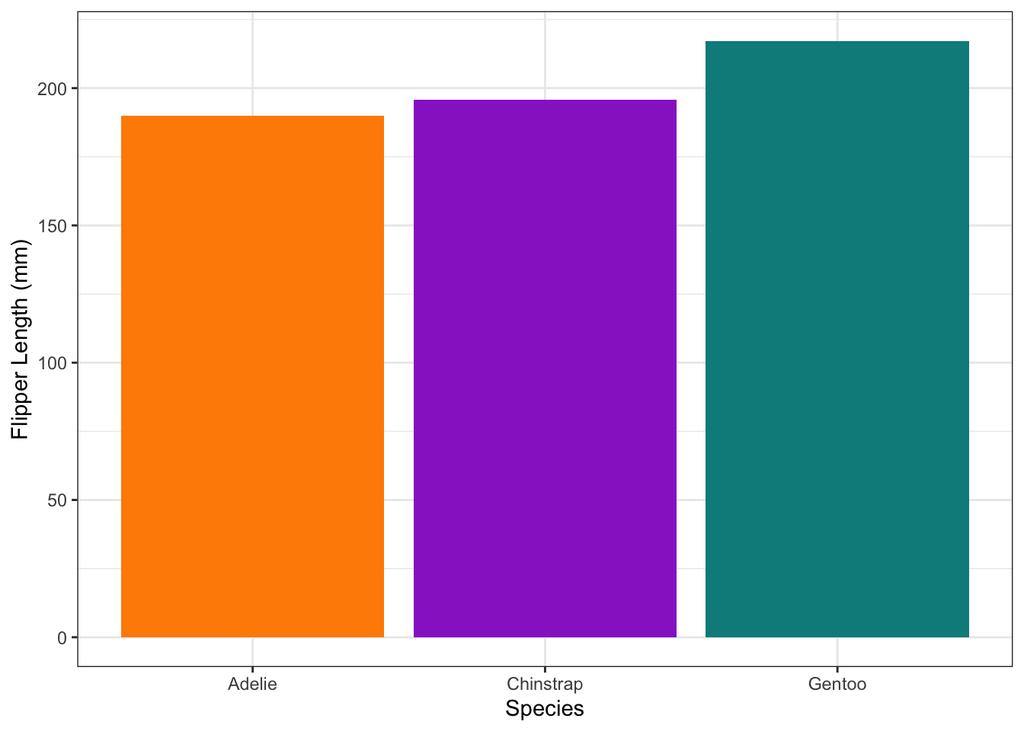

```r
penguins%>%
  group_by(species)%>%
  summarise(mean_flipper = mean(flipper_length_mm, na.rm = T))%>%
  ggplot(aes(x = species, y = mean_flipper))+
    geom_bar(stat = "identity", fill = c("darkorange","darkorchid","cyan4"))+
    theme_bw()+
    labs(x = "Species",
         y = "Flipper Length (mm)")
```

##2. Make a scatter plot of bill length compared to bill depth but only for observations on the Dream island.

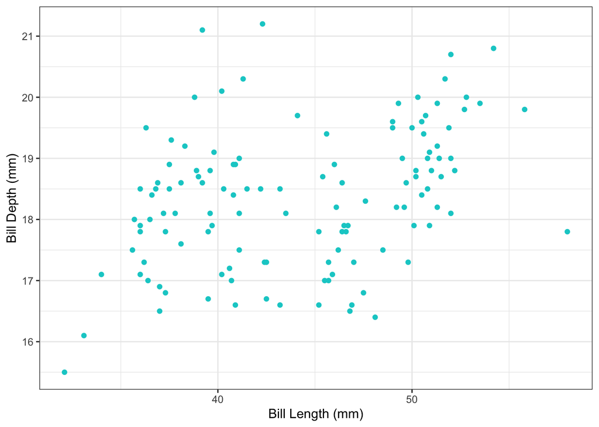

```r
ggplot(penguins) +
  geom_point(filter(penguins, island == "Dream"),
             mapping = aes(x = bill_length_mm, y = bill_depth_mm), color = "cyan3")+
  theme_bw()+
  labs(x = "Bill Length (mm)",
       y = "Bill Depth (mm)")
```